# RR-PA-1

This is an R markdown document being created for DASI-RR-PA-I

Read the data from a csv file. The csv file is expected to be in the current working directory

1. Load useful R libraries for further structuring of the data

```r
        library(plyr)
        library(dplyr)
        library(reshape2)
        library(data.table)
        library(lattice)
        library(scales)
        library(ggplot2)
        library(tables)
        library(knitr)
```

2. Loading and Preprocessing the data
- Read csv file and create a data table

```r
  activity.data<-read.csv("activity//activity.csv",row.names=NULL,
                          col.names=c("steps","on.date","interval"))
  activity.data <-data.table(activity.data)
```

- How does the data look like ? - Print the first 5 rows

```
##    steps    on.date interval
## 1:    NA 2012-10-01        0
## 2:    NA 2012-10-01        5
## 3:    NA 2012-10-01       10
## 4:    NA 2012-10-01       15
## 5:    NA 2012-10-01       20
```

2. Preprocess the Activity data
   - Restructure the data for plots
   - Pre-process by removing the NAs
   - Compute the total steps for each day

```r
  freq.tbl<-activity.data[!is.na(steps), list(total.steps = sum(steps)),
                                         by = list(on.date = as.Date(on.date))]
```

- Print restructured data table

```
## [1] 53
```

```
##       on.date total.steps
## 1: 2012-10-02         126
## 2: 2012-10-03       11352
## 3: 2012-10-04       12116
## 4: 2012-10-05       13294
## 5: 2012-10-06       15420
```

3. What is mean total number of steps taken per day?
- Make a histogram of the total number of steps taken each day

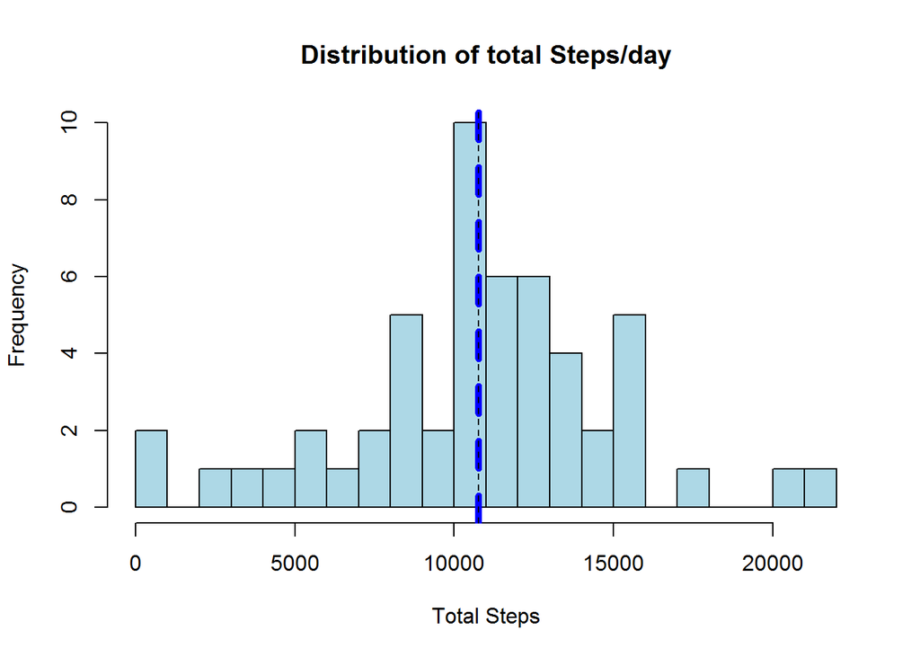

```r
  hist(na.omit(freq.tbl$total.steps),breaks =20,
               main = "Distribution of total Steps/day",
               xlab = "Total Steps",col = "lightblue")

  # add the mean and median lines to the histogram
  abline(v = mean(freq.tbl$total.steps), col = "blue", lty = 2 , lwd = 5)
  abline(v = median(freq.tbl$total.steps), col = "black", lty = 2, lwd = 1)
```

- Calculate and report the mean and median total number of steps taken per day

`## [1] "Mean & Median :"`

`## [1] 10766.19`

`## [1] 10765`

3. What is the average daily activity pattern?
- Make a time series plot (i.e. type = “l”) of the 5-minute interval (x-axis) and the average number of steps taken, averaged across all days (y-axis)
- Make a TS plot with mean steps for each 5 minute interval.

```
##    mean.steps interval
## 1:  1.7169811    05:30
## 2:  0.3396226    05:35
## 3:  0.1320755    05:40
## 4:  0.1509434    05:45
## 5:  0.0754717    05:50
```

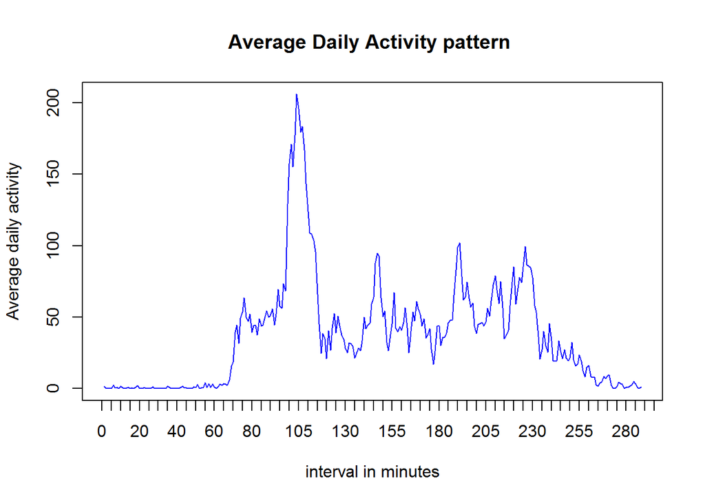

- Which 5-minute interval, on average across all the days in the dataset, contains the maximum number of steps?
- Order the data table and print the first row

```r
    max.val<-ts.tbl[order(ts.tbl$mean.steps, decreasing = T)]
    print(max.val[1:5,])
```

```
##    mean.steps interval
## 1:   206.1698    19:25
## 2:   195.9245    19:30
## 3:   183.3962    19:40
## 4:   179.5660    19:35
## 5:   177.3019    19:20
```

```r
    print("Max value and 5 minute interval:")
```

```
## [1] "Max value and 5 minute interval:"
```

```r
    print(max.val[1,])
```

```
##    mean.steps interval
## 1:   206.1698    19:25
```

```
4.  Imputing missing values

* Calculate and report the total number of missing values in the dataset

* Draw a bar plot to indicate the number of NAs (miss.vals)
  (i.e. the total number of rows with NAs)
```

```
##    missing.values complete.values
## 1:           2304           15264
```

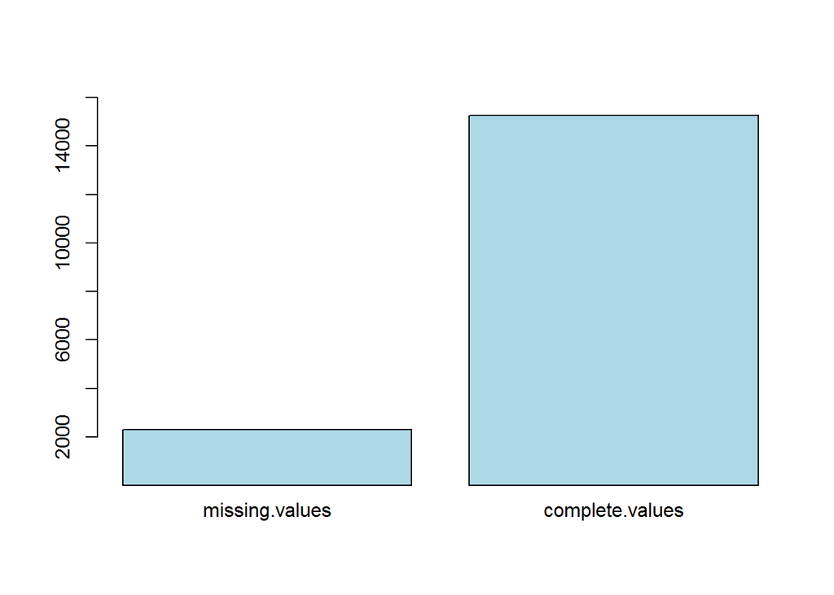

```
* Devise a strategy to fill missing values in the dataset
* Compute the mean without NAs, use that mean for each interval combination
  to impute     the NAs
```

```r
      impute.mean <- function(x) replace(x, is.na(x), mean(x, na.rm = TRUE))

      imputed.data <- ddply(activity.data, .(interval), transform,
                      steps = impute.mean(steps))

      imputed.data<-data.table(imputed.data)

      print(imputed.data[1:10,])
```

```
##         steps    on.date interval
##  1:  1.716981 2012-10-01        0
##  2:  0.000000 2012-10-02        0
##  3:  0.000000 2012-10-03        0
##  4: 47.000000 2012-10-04        0
##  5:  0.000000 2012-10-05        0
##  6:  0.000000 2012-10-06        0
##  7:  0.000000 2012-10-07        0
##  8:  1.716981 2012-10-08        0
##  9:  0.000000 2012-10-09        0
## 10: 34.000000 2012-10-10        0
```

```r
      new.freq.tbl<-imputed.data[, list(total.steps = sum(steps)), by = on.date]
```

- Plot the histogram for the new distribution of activity

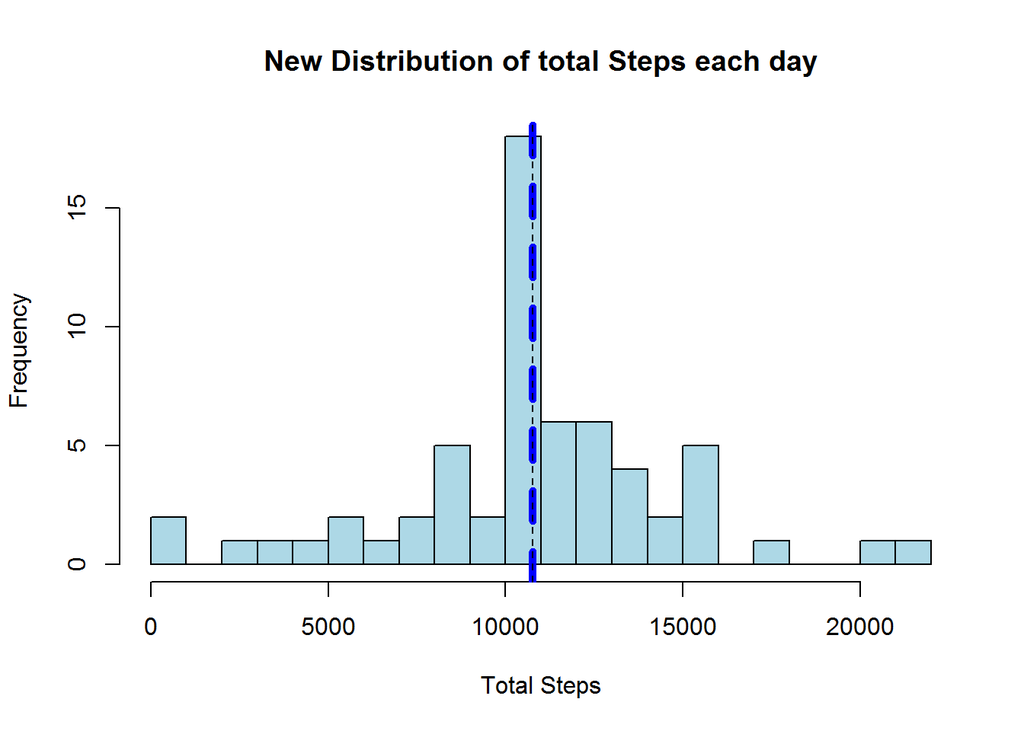

```
## [1] "New Mean & New Median:"
```

```
## [1] 10766.19
```

```
## [1] 10766.19
```

- Do these values differ from the estimates from the first part of the assignment? What is the impact of imputing missing data on the estimates of the total daily number of steps?
- Compute the difference between original Mean and Media v.s New Mean and Median

```
## [1] "Is there a difference in Mean and Median estimates from the first:"
```

```
## [1] "Difference in Mean is equal to 0?"
```

```
## [1] TRUE
```

```
## [1] 0
```

```
## [1] "Difference in Median is equal to 0?"
```

```
## [1] FALSE
```

```
## [1] 1.188679
```

```
## [1] "Difference in sum of total steps is equal to 0?"
```

```
## [1] TRUE
```

5. Are there differences in activity patterns between weekdays and weekends?
   1. Create a new factor variable in the dataset with two levels - “weekday” and “weekend” indicating whether a given date is a weekday or weekend day.
   2. Make a panel plot containing a time series plot (i.e. type = “l”) of the 5-minute interval (x-axis) and the average number of steps taken, averaged across all weekday days or weekend days (y-axis).

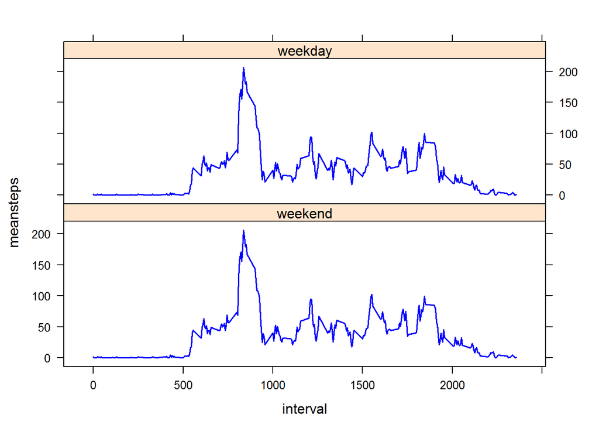

```
## [1] "From the panel plot, it can be observed that there is no difference between a week-end and a week-day activity "
```